# Proble Set 1: Prediciendo el ingreso

Maria Camila Caraballo, Javier Amaya, Nicolas Moreno, Mateo Isaza

2025-02-01

```r
knitr::opts_chunk$set(echo = TRUE)

# Limpieza del ambiente
  rm(list = ls())
  cat("\f")
```

```r
# Cargando los paquetes requeriods para el analisis
library(pacman)


p_load(rio,
       tidyverse,
       caret,
       gridExtra,
       skimr,
       stargazer,
       boot,
       rvest,
       ggplot,
      parallel,
      AER
)

# Declarando las rutas
data_raw_path <- "../data/raw"
data_processed_path <- "../data/processed"
table_results_path <- "../results/tables"
figure_results_path <- "../results/figures"
```

# 1. Introducción

*Uno de los principales desafíos para la equidad tributaria y la sostenibilidad fiscal en Colombia es la subdeclaración de ingresos, una práctica facilitada por la ausencia de información precisa sobre los ingresos reales de los contribuyentes. Esto en particular, afecta tanto al sector formal como el informal, dificultando la correcta determinación de la base gravable y generando distorsiones en la distribución de la carga tributaria.*

*En este sentido, la subdeclaración de ingresos incide directamente en el déficit fiscal del país, que, según el **Marco Fiscal de Mediano Plazo**, representa aproximadamente el 5,6% del Producto Interno Bruto (PIB), equivalente a cerca de **US$17.000 millones anuales**. En un contexto donde el Gobierno busca fortalecer su capacidad de inversión y cumplir con compromisos sociales, la insuficiencia de ingresos tributarios aumenta la necesidad de recurrir al endeudamiento público, poniendo en riesgo la sostenibilidad del gasto. Asimismo, esta limitación compromete la capacidad del Estado para financiar servicios esenciales y ejecutar programas sociales, afectando de manera directa a las poblaciones más vulnerables y profundizando las desigualdades estructurales del país.*

*La mejora en la distribución del ingreso, más allá de la simple reducción de la pobreza, se ha convertido en un objetivo prioritario de la política pública en general y de la política fiscal en particular (Henríquez, 2015). En este contexto, la alta informalidad en la economía colombiana agrava la problemática de la subdeclaración, ya que un gran volumen de transacciones quedan fuera del control del Estado, impidiendo una redistribución eficiente de los recursos.*

*Considerando lo anterior, la implementación de modelos predictivos en la fiscalización tributaria representa una herramienta clave para mejorar la detección de fraudes fiscales y optimizar la recaudación. Estos modelos no solo permiten identificar con mayor precisión a los evasores, sino que también fortalecen la equidad en la distribución de la carga impositiva, lo que a su vez favorece una asignación más eficiente de los recursos destinados al financiamiento de políticas sociales. Asimismo, su aplicación contribuye a reducir los costos administrativos de los métodos tradicionales de fiscalización y a abordar el problema del subreporte de información, mejorando la calidad y precisión de los datos tributarios, facilitando la elaboración de presupuestos más ajustados a la realidad fiscal del país y promoviendo una gestión pública más eficiente.*

De esta manera, el principal objetivo es construir un modelo de salario por horas individual:

$$w = f(X) + u$$

# 2. Datos

2.1) Describa el proceso de adquisición de los datos y si existen restricciones para acceder a ellos o para realizar scraping.

*A partir del enlace [**GEIH 2018 Sample**](https://ignaciomsarmiento.github.io/GEIH2018_sample/page1.html), se analizó el código HTML subyacente para identificar la etiqueta correspondiente a la tabla que contenía los datos de interés. Sin embargo, al extraer la información, el resultado obtenido fue un objeto vacío. Para abordar este desafío, se inspeccionó la pestaña Network del inspector web con el fin de analizar la secuencia de carga de los elementos.*

*Durante este análisis, se identificó que el archivo con los datos requeridos estaba asociado a una [Request URL específica](https://ignaciomsarmiento.github.io/GEIH2018_sample/pages/geih_page_1.html). Una vez localizada la fuente de los datos, se empleó la técnica de web scraping aprendida en clase, utilizando el paquete `rvest` en R, para extraer la información de manera estructurada. Posteriormente, se implementó un bucle que se ejecutó 10 veces, permitiendo iterar sobre las distintas páginas de datos, concatenando progresivamente las tablas extraídas. Como resultado, se obtuvo un dataframe con dimensiones 32,177 x 177.*

2.2) Describa el proceso de limpieza de los datos.

#### Proceso de filtrado y preparación de datos

*Para el análisis, se filtró la base de datos para incluir únicamente las observaciones correspondientes a individuos ocupados (`ocu == 1`) mayores de edad (`age ≥ 18`). Con el fin de garantizar la coherencia de los datos, se verificó que la población en edad de trabajar (`wap == 1`) incluyera tanto a la población económicamente activa (`pea == 1`) como a la población inactiva (`inac == 1`). Asimismo, se corroboró que la población económicamente activa estuviera compuesta por individuos ocupados y desocupados (`dsi == 1`). Una vez confirmada la consistencia de estas categorías, se procedió con el filtrado de datos.*

*Posteriormente, se asignó un identificador único a cada observación mediante la concatenación de los valores de las variables directorio, secuencia_p y orden, que corresponden al identificador de vivienda, hogar y persona, respectivamente. Previo a este procedimiento, se verificó que la combinación de estos códigos fuera única para cada fila, garantizando la integridad en la identificación individual.*

#### Construcción de variables

*Una vez establecidos los filtros y asignados los identificadores, se seleccionaron las variables relevantes para el análisis. En primer lugar, la variable dependiente se construyó a partir de la suma de diversas categorías de ingresos (`impa`, `impaes`, `isa`, `isaes`, `ie`, `iees`, `p6630s4a1`). En particular, la variable `p6630s4a1`, que representa el valor de los viáticos recibidos en el año anterior, fue ajustada dividiéndola entre 12 para mantener la unidad temporal mensual, alineándola con el resto de los conceptos de ingresos.*

*Adicionalmente, se construyó una variable representativa de las horas trabajadas mensualmente por cada individuo. Para ello, se utilizaron las variables `hoursWorkUsual` y `hoursWorkActualSecondJob`, que indican la cantidad de horas trabajadas durante la semana anterior. Para obtener una estimación anual, multiplicamos ambas variables por 49, asumiendo que en Colombia se trabajan 52 semanas al año menos tres semanas correspondientes a los 15 días hábiles de vacaciones que, en promedio, los trabajadores formales reciben anualmente. Finalmente, dividimos el resultado entre 12 para obtener la estimación mensual de horas trabajadas y sumamos ambas columnas para obtener el total de horas trabajadas por mes.*

#### Ajustes finales

*Finalmente, con el fin de facilitar la interpretación de la variable `sex`, invertimos su codificación y la renombramos como `female`, de modo que su valor fuera 0 para hombres y 1 para mujeres, siguiendo las especificaciones del taller en cuanto a las variables de interés.*

2.3) Describa las variables incluidas en su análisis. Como mínimo, se debe incluir una tabla de estadísticas descriptivas con su interpretación. Sin embargo, espero un análisis profundo que ayude al lector a comprender los datos, su variación y la justificación de la elección de los datos. Utilice su conocimiento profesional para agregar valor a esta sección. No lo presente como una lista “seca” de ingredientes.

*La decisión de construir nuestra propia variable de ingresos por hora, **log_hourly_inglab**, se fundamentó en dos razones principales: una metodológica y otra basada en intuición económica. Desde un punto de vista metodológico, la variable de ingresos por hora disponible creada en la base de datos inicial `y_salary_m_hu` presentaba una cantidad considerable de valores faltantes, lo que reducía la muestra en aproximadamente un 40% tras la aplicación de los filtros de selección. Esta pérdida de observaciones habría limitado el análisis, disminuyendo la robustez de las estimaciones.*

*Por otro lado, desde una perspectiva de intuición económica, el análisis detallado de la documentación de la GEIH reveló la existencia de variables adicionales que permitían estimar de manera más integral los ingresos laborales. Para su cálculo, se tomaron en cuenta múltiples fuentes de ingreso laboral, siguiendo el concepto de rentas laborales definido por la Dirección de Impuestos y Aduanas Nacionales (DIAN), el cual incluye exclusivamente ingresos derivados de la actividad laboral de una persona.*

*Para ello, se combinaron diversas categorías de ingresos laborales con el objetivo de minimizar la cantidad de valores faltantes. Las versiones imputadas y no imputadas de cada fuente de ingreso laboral permitó obtener una variable consolidada que luego se sumó junto con el ingreso en especie y los viáticos ajustados a valores mensuales. De esta manera, se mejora la calidad de la variable dependiente, alineándola con la realidad económica del país.*

*Entre las variables explicativas, se incluyó la **edad**, dado que es un factor reconocido en la literatura como determinante del ingreso laboral pues refleja tanto la acumulación de experiencia como la posible depreciación del capital humano en edades avanzadas. Esta variable obtuvo como media 39 años, con un rango que oscila entre los 18 y los 94 años, mostrando una distribución aproximadamente normal.*

*Como parte del anális, se incorporó la variable de género para analizar la brecha de ingresos entre hombres y mujeres, a su vez que permite evaluar si incluso controlando por otras características individuales y laborales, persisten disparidades en su ingreso. La variable **female**, que identifica a las mujeres en la muestra, refleja una distribución del 47% para mujeres y 53% para hombres.*

*Asimismo, se incluyó el **nivel educativo** como un factor determinante en los ingresos. Esta variable toma valores de 1 a 6, donde 1 corresponde a personas sin educación formal y 6 a aquellas con educación universitaria, mientras que los valores intermedios representan distintos niveles educativos. En la muestra, con la frecuencia más alta se encuentra la categoría 5, lo que indica que la educación secundaria es el nivel educativo más recurrente entre los entrevistados.*

Incorporamos también la variable **cuentaPropia** correspondiente a 1 si el individuo trabaja como independiente y 0 de lo contrario. Para nuestra muestra, aproximadamente el 31% de los individuos trabajaba como independiente lo que equivale a 5106 observaciones del total.

*De igual manera, se consideró que las características laborales desempeñan un papel clave en las diferencias salariales. Por esta razón, se incluyó la variable de **oficio**, que clasifica a los individuos según su actividad económica. Dicha variable abarca 80 categorías distintas y permite identificar cómo la remuneración varía entre sectores y tipos de empleo. En la muestra, las ocupaciones más frecuentes corresponden a vendedores ambulantes, domiciliarios, vendedores de loterías, periódicos y comerciantes.*

*Por otro lado, se incorporó la variable de **relación laboral**, la cual distingue entre trabajadores asalariados, independientes y otras formas de vinculación laboral. Esta variable cuenta con nueve categorías, siendo las más comunes las de obrero o empleado de una empresa particular. De este modo, su inclusión permite evaluar cómo el tipo de vínculo laboral influye en la estructura salarial y en las posibles diferencias en los ingresos.*

*Otra de las variables clave para el análisis es **formal,** la cual indica si un trabajador está afiliado a la seguridad social. Su inclusión permite diferenciar entre empleos que ofrecen mayor estabilidad y beneficios frente a aquellos en condiciones más precarias, lo que es relevante para evaluar desigualdades en el ingreso por actividad laboral. En nuestra muestra, el 58.6% de los individuos se clasifica como formal, una cifra consistente con el 60.7% reportado en el Boletín Técnico GEIH del DANE para el periodo diciembre 2018 - febrero 2019 en Bogotá, lo que refuerza la representatividad de los datos.*

*Finalmente, se incorporó el **estrato socioeconómico** como un indicador complementario de las condiciones de vida de los individuos, proporcionando contexto sobre las diferencias en acceso a bienes y servicios. Esta variable oscila entre 1 y 6, con una media de 2.6 y una mediana de 2. Su distribución muestra un sesgo hacia la derecha, ya que hasta el percentil 75 los individuos pertenecen al estrato 3. Esto sugiere que solo el 25% de la muestra reside en estratos superiores, lo que refleja la concentración de la población en niveles socioeconómicos bajos y medios.*

*El tamaño de la empresa, es una variable categórica cuyos valores corresponden a: i) 1 si el individuo es independiente; ii) 2 si el individuo trabaja e una empresa con 2 a 5 trabajadores; iii) 3 si el individuo trabaja en una empresa con 6 a 10 trabajadores; iv) 4 si el individuo trabaja en una empresa con 11 a 50 trabajadores; y v) 5 si el individuo trabaja en una empresa con más de 50 trabajadores. En este caso la media es de 3.15 y la mediana de 3, lo que sugiere que la distribución está sesgada hacia valores más altos, pero con predomino de individuos trabajando en empresas pequeñas de entre 6 y 10 trabajadores. Dado que la desviación estándar es 1.649, la dispersión de los datos es relativamente baja, lo que sugiere una concentración en empresas de tamaño reducido. La distribución no parece seguir una forma normal, ya que la mediana y la media no coinciden y hay una posible asimetría hacia valores más altos.*

*Finalmente, la antigüedad en la empresa, medida en meses, presenta una media de 63.76 meses y una mediana de 24 meses. Este contraste indica que la distribución está sesgada hacia valores más altos, con algunos empleados con una larga permanencia en la empresa. El rango es amplio, desde 0 hasta 720 meses, lo que evidencia la presencia de empleados recientes y otros con una gran trayectoria dentro de la organización. La alta desviación estándar de 89.488 refuerza la idea de una distribución altamente dispersa y no normal, con una fuerte asimetría debido a valores extremos en los empleados con mayor antigüedad.*

```r
# Haciendo el webscraping -
# Funciona pero lo desactivo mientras trabajamos. Hay que activarlo al final
  # tabla_geih <- data.frame()

  # for (i in 1:10){
    # my_url <- sprintf("https://ignaciomsarmiento.github.io/GEIH2018_sample/pages/geih_page_%d.html", i)
    # my_table <- read_html(my_url) %>%
     #  html_elements(xpath='/html/body/table') %>%
     #  html_table()

  #   my_table <- as.data.frame(my_table)

  #   tabla_geih <- rbind(tabla_geih, my_table)

  #   rm(my_table)

  # }

tabla_geih <- readRDS(file.path(data_raw_path,"Data_GEIH_raw_2.rds"))

# Limpieza de los datos
clean_geih <- tabla_geih %>%
  filter(age >= 18, ocu == 1) %>%
  mutate(
    directorio = as.factor(directorio),
    secuencia_p = as.factor(secuencia_p),
    orden = as.factor(orden),
    id = paste(directorio, secuencia_p, orden, sep = "")) %>%
  select(
    # Variables demográficas
    'id', # Identificador único por individuo
    'age', # Edad
    'sex', # Sexo
    'p6210', # Nivel educativo alcanzado
    'p6426', #antiguedad en la empresa

    # Variables para utilizar en el cálculo de los ingresos por hora
    'impa', # Ingreso mensual por la primera actividad antes de imputación
    'impaes', # Ingreso mensual imputado por la primera actividad
    'isa', # Ingreso mensual por la segunda actividad antes de imputación
    'isaes', # Ingreso mensual imputado por la segunda actividad
    'ie', # Ingreso mensual en especie antes de imputación
    'iees', # Ingreso mensual en especia imputado
    'p6630s4a1', # Valor anual viáticos
    'hoursWorkUsual', # Horas trabajadas en la última semana
    'hoursWorkActualSecondJob', # Horas trabajadas en la última semana por la segunda actividad

    # Otras variables de interes
    'formal', # empleo formal
    'sizeFirm', # tamaño de la firma
    'oficio', # Oficio de la persona
    'relab', # tipo de ocupación
    'cuentaPropia', # Independiente
    'estrato1', # Estrato
    )

# Calculando la variable viáticos anuales a viáticos mensuales
clean_geih <-  clean_geih %>%
  mutate(p6630s4a1 = p6630s4a1 / 12)

# Sumando los ingresos por diferentes conceptos para cada persona
clean_geih$inglab <- rowSums(clean_geih[, c(
  'impa',
  'impaes',
  'isa',
  'isaes',
  'ie',
  'iees',
  'p6630s4a1'
)], na.rm=TRUE)

# Revisión de la variable ingresos laborales calculada
sum(is.na(clean_geih$inglab)) # no tenemos NAs en la variable
```

[1] 0

```r
sum(clean_geih$inglab == 0) # tenemos 323 observaciones con ingresos = a cero lo cual no tiene sentido.
```

[1] 323

```r
# Imputaciôn de promedio de ingresos por estrato y sexo para valores de ingreso que son iguales a cero.
clean_geih <- clean_geih %>%
  group_by(estrato1, sex) %>%
  mutate(mean_inglab = mean(inglab[inglab != 0], na.rm = TRUE)) %>%
  ungroup() %>%
  mutate(inglab = ifelse(inglab == 0, mean_inglab, inglab)) %>%
  as.data.frame()

# Cálculo e imputación de horas trabajadas por mes
clean_geih <- clean_geih %>%
  mutate(hour_month1 = (hoursWorkUsual * 49) / 12) %>%
  mutate(hour_month2 = (hoursWorkActualSecondJob * 49) / 12)

clean_geih$total_hours <- rowSums(clean_geih[, c('hour_month1', 'hour_month2')], na.rm=TRUE)
summary(clean_geih$total_hours)
```

Min. 1st Qu. Median Mean 3rd Qu. Max. 4.083 163.333 196.000 193.561 204.167 530.833

```r
# Cálculo de ingresos laborales por hora
clean_geih <- clean_geih %>%
  mutate(hourly_inglab = inglab / total_hours)

# Convirtiendo la variable sexo a female
clean_geih <- clean_geih %>%
  #Transformación directa de variables de interés para el modelo
  mutate(age_sq = age^2) %>%
  mutate(female = ifelse(sex == 1, 0, 1)) %>%   # Variable female para el análisis de brecha de género
  mutate(p6210 = ifelse(p6210 == 9, 1, p6210)) %>%
  mutate(log_hourly_inglab = log(hourly_inglab)) %>% # creando la variable log del salario hora
  select(                                            # seleccionando las variables
    'id',
    'hourly_inglab',
    'log_hourly_inglab',
    'age',
    'age_sq',
    'female',
    'p6210',
    'cuentaPropia',
    'estrato1',
    'formal',
    'sizeFirm',
    'oficio',
    'relab',
    'p6426')

stargazer(clean_geih,
          type = "html",
          title = "Tabla 1. Estadísticas descriptivas",
          align = TRUE,
          no.space = TRUE,
          omit = c(5),
          nobs = FALSE,
          median = TRUE,
          covariate.labels = c(
            "Ingreso por hora", "Log ingreso por hora", "Edad",
            "Mujer", "Nivel educativo", "Independiente", "Estrato", "Formal",
            "Tamaño de la empresa", "Tipo de oficio", "Categoría laboral",
            "Antigüedad en la empresa"),
          notes = c(
            "Todas las variables usadas en este trabajo provienen de la GEIH de Bogotá para 2018. \\\\",
            "Número de observaciones: 16,542 para todas las variables. Nuestra variable explicada \\\\",
            "es Log ingreso por hora que corresponde al logaritmo de los ingresos por hora para \\\\",
            "cada individuo. Ingreso por hora se encuentra expresado en pesos colombianos (COP)."
          ),
          notes.append = FALSE,
          out = file.path(table_results_path, "2_1_table_estadisticas_descriptivas.html")
          )
```

**Tabla 1. Estadísticas descriptivas**

| Statistic | Mean | St. Dev. | Min | Median | Max |
| --- | --- | --- | --- | --- | --- |
| Ingreso por hora | 9,677.007 | 17,465.710 | 81.633 | 5,323.182 | 888,775.500 |
| Log ingreso por hora | 8.722 | 0.856 | 4.402 | 8.580 | 13.698 |
| Edad | 39.436 | 13.483 | 18 | 38 | 94 |
| Mujer | 0.470 | 0.499 | 0 | 0 | 1 |
| Nivel educativo | 5.000 | 1.099 | 1 | 5 | 6 |
| Independiente | 0.309 | 0.462 | 0 | 0 | 1 |
| Estrato | 2.551 | 1.011 | 1 | 2 | 6 |
| Formal | 0.587 | 0.492 | 0 | 1 | 1 |
| Tamaño de la empresa | 3.152 | 1.649 | 1 | 3 | 5 |
| Tipo de oficio | 49.773 | 28.080 | 1 | 45 | 99 |
| Categoría laboral | 2.268 | 1.547 | 1 | 1 | 9 |
| Antigüedad en la empresa | 63.758 | 89.488 | 0 | 24 | 720 |
| Todas las variables usadas en este trabajo provienen de la GEIH de Bogotá para 2018. |  |  |  |  |  |
| Número de observaciones: 16,542 para todas las variables. Nuestra variable explicada |  |  |  |  |  |
| es Log ingreso por hora que corresponde al logaritmo de los ingresos por hora para |  |  |  |  |  |
| cada individuo. Ingreso por hora se encuentra expresado en pesos colombianos (COP). |  |  |  |  |  |

% Table created by stargazer v.5.2.3 by Marek Hlavac, Social Policy Institute. E-mail: marek.hlavac at gmail.com % Date and time: lun, mar. 03, 2025 - 10:38:34 p. m. % Requires LaTeX packages: dcolumn

# 3. Perfil ingreso - edad

Una gran cantidad de evidencia en economía laboral sugiere que el perfil típico de edad-salario de los trabajadores sigue un patrón predecible: los salarios tienden a ser bajos cuando el trabajador es joven, aumentan a medida que envejece, alcanzando su punto máximo alrededor de los 50 años, y luego tienden a mantenerse estables o disminuir ligeramente después de esa edad. En esta subsección, estimaremos el perfil de edad-salario para los individuos de esta muestra.

$$log(w) = \beta_1 + \beta_2Edad + \beta_3 Edad^2 + u$$
Al presentar y discutir tus resultados, incluye:

- Una tabla de regresión.

  ```r
  #Calculamos el modelo
  modelo_edad <- lm(log_hourly_inglab ~ age + age_sq, data = clean_geih)

  #Organizar las etiquetas
  custom_labels <- list(
    "(Constant)" = "Intercepto",
    "age" = "Edad",
    "age_sq" = "Edad^2")

  # Tabla de resultados
  stargazer (modelo_edad, type = "html",
            title = "Tabla 1 - Perfil de Edad-Ingresos",
            dep.var.labels = "Log Ingresos por hora",
            no.space = TRUE,
            keep.stat = c("n", "rsq"),
            star.cutoffs = NA,
            out = file.path(table_results_path, "3_1_Tabla_Edad.html"))
  ```

  **Tabla 1 - Perfil de Edad-Ingresos**

  |  | *Dependent variable:* |
  | --- | --- |
  |  | Log Ingresos por hora |
  | age | 0.041 |
  |  | (0.003) |
  | age_sq | -0.0005 |
  |  | (0.00003) |
  | Constant | 7.917 |
  |  | (0.057) |
  | Observations | 16,542 |
  | R<sup>2</sup> | 0.013 |
  | *Note:* | NA |

% Table created by stargazer v.5.2.3 by Marek Hlavac, Social Policy Institute. E-mail: marek.hlavac at gmail.com % Date and time: lun, mar. 03, 2025 - 10:38:36 p. m.

- Una interpretación de los coeficientes y su significancia.

*La transformación de los datos en el modelo permite capturar relaciones no lineales entre la edad y el ingreso laboral por hora, lo que resulta fundamental para comprender cómo varía el efecto de la edad a lo largo de la vida laboral. En este caso, la inclusión del término cuadrático responde a la necesidad de modelar un comportamiento que no es constante: aunque el salario tiende a aumentar con la edad, este crecimiento no es indefinido.*

*Los coeficientes obtenidos, ambos significativos, indican que existe un punto máximo a partir del cual la edad deja de ser un factor positivo en el incremento salarial y, en su lugar, comienza a generar rendimientos decrecientes. Específicamente, el coeficiente positivo del término lineal de la edad sugiere que, en las primeras etapas de la vida laboral, el salario crece a medida que una persona adquiere experiencia y habilidades. Sin embargo, el coeficiente negativo del término cuadrático evidencia que este crecimiento se desacelera con el tiempo y, eventualmente, se revierte, lo que implica que los aumentos salariales se reducen hasta alcanzar un umbral en el que la edad deja de ser un factor de incremento.*

*Esta transformación, por tanto, permite capturar la evolución realista de los ingresos a lo largo del ciclo laboral, proporcionando una interpretación más precisa del impacto de la edad sobre el salario y evitando suposiciones erróneas de una relación lineal constante.*

- Una discusión sobre el ajuste del modelo dentro de la muestra.

*El error cuadrático medio (MSE) dentro de la muestra se emplea como criterio para evaluar y comparar el ajuste de distintos modelos, dado que mide la precisión de las predicciones. En este caso, el MSE obtenido fue de **0.72**, lo que sirve como referencia para contrastar modelos posteriores, favoreciendo aquellos con un menor MSE. En términos generales, este valor es útil principalmente para medir el grado de ajuste y establecer comparaciones entre modelos.*

```r
#MSE dentro de la muestra
pred <- predict(modelo_edad, clean_geih)
mse <- mean((clean_geih$log_hourly_inglab - pred)^2)
mse
```

```
## [1] 0.7226224
```

- Un gráfico del perfil estimado de edad-ingresos implícito en la ecuación anterior, incluyendo un análisis de la edad en la que se alcanza el pico con sus respectivos intervalos de confianza. *(Nota: Usa bootstrap para construir los intervalos de confianza.)*

  ```r
  #Se calcula el valor máximo de la edad
  coefs <- coef(modelo_edad)
  beta1 <- coefs[1]
  beta2 <- coefs[2]
  beta3 <- coefs[3]

  #Valor de la edad máxima
  age_max <- (-beta2/(2*beta3))
  print(age_max)
  ```

  ```
  ##      age
  ## 43.39676
  ```

  ```r
  #Desarrollamos la función para el bootstrap
  boot_func <- function(data,index)
  {
      boot_sample <- data[index, ]
      boot_model <-lm(log_hourly_inglab ~ age + age_sq, data = data, subset = index)
      beta2 <- boot_model$coefficients[2]
      beta3 <-  boot_model$coefficients[3]
      return(- beta2/ (2 * beta3))
  }

  #Se aplica el bootstrap
  boot_age <- boot(clean_geih, boot_func, 10)

  # Extraer estimaciones
  age_coefs <- apply(boot_age$t, 2, mean)  # Media de los coeficientes
  age_coefs
  ```

  ```
  ## [1] 43.431
  ```

  ```r
  #Para obtener los intervalos de confianza usando bootstrap
  conf_int <- boot.ci(boot_age, type = "perc")
  conf_int
  ```

  ```
  ## BOOTSTRAP CONFIDENCE INTERVAL CALCULATIONS
  ## Based on 10 bootstrap replicates
  ##
  ## CALL :
  ## boot.ci(boot.out = boot_age, type = "perc")
  ##
  ## Intervals :
  ## Level     Percentile
  ## 95%   (42.51, 44.95 )
  ## Calculations and Intervals on Original Scale
  ## Warning : Percentile Intervals used Extreme Quantiles
  ## Some percentile intervals may be unstable
  ```

  ```r
  #Estimaciones
  perfil_pred <- function(age, coef) {
    log_sal_pred <- coef[1] + coef[2] * age + coef[3] * age^2
    return(exp(log_sal_pred))
  }

  # Rangos de edades
  age_range <- seq(min(clean_geih$age), max(clean_geih$age), 1)

  #Perfil estimado
  pred_profile <- perfil_pred(age_range, coef(modelo_edad))

  # Bootstrap para intervalos de confianza del perfil
  boot_perfiles <- sapply(1:1000, function(i) {
    sample_data <- clean_geih[sample(nrow(clean_geih), replace = TRUE), ]
    modelo_boot <-lm(log_hourly_inglab ~ age + age_sq, data = sample_data)
    perfil_pred(age_range, coef(modelo_boot))
  })

  ci_perfil <- apply(boot_perfiles, 1, quantile, probs = c(0.025, 0.975))

# 4. Brecha salarial por género

Los formuladores de políticas han estado preocupados durante mucho tiempo por la brecha salarial de género, y este será nuestro enfoque en esta subsección.

**a. Comience estimando y discutiendo la brecha salarial incondicional:**

$$log(w) = \beta_1 + \beta_2Female + u$$

donde *Female* es un indicador que toma el valor de uno si el individuo en la muestra se identifica como mujer.

**Tabla 4-1. Resultados del modelo incondicional**

|  | Logaritmo del ingreso |
| --- | --- |
| Female | -0.062 |
|  | (0.013) |
| Observations | 16,542 |
| R<sup>2</sup> | 0.001 |
| Adjusted R<sup>2</sup> | 0.001 |
| *Note:* | Errores estándar en paréntesis; No incluye controles |

% Table created by stargazer v.5.2.3 by Marek Hlavac, Social Policy Institute. E-mail: marek.hlavac at gmail.com % Date and time: lun, mar. 03, 2025 - 10:39:17 p. m.

Utilizando como referencia el “unconditional model” podemos discutir sobre los siguientes puntos:

- Para el caso del intercepto, podemos sacarle el exponente para obtener el salario promedio de los hombres que llega a $ 6315 por hora.
- En cuanto al coeficiente de *female* en el que se puede observar que dicho coeficiente es estadisticamente diferente de cero (*p value= 0.00001*), podemos interpretar que en promedio el salario por hora de las mujeres es un 6.15% más bajo que el salario de los hombres.
- En cuanto al $R^2$ ajustado se puede observar que es del 0.12% lo que quiere decir que el modelo utilizando solo variable de *female* explica el 0.12% de la variabilidad del logaritmo del ingreso por hora. De alguna manera, esta es esperable porque solo tenemos una variable predictora y esto deja por fuera otras variables que pueden ser relevantes como la educación, la edad, la experiencia, entre otras.

**b. Un eslogan común es “igual salario por igual trabajo”. Una forma de interpretar esto es que, para empleados con características laborales y personales similares, no debería existir una brecha salarial de género. Para analizar esto, estima la brecha salarial condicional incorporando variables de control como características del trabajador y del puesto de trabajo.**

Para llevar a cabo esta estimación de un modelo condicional se consideraron dos grandes grupos de variables control que pueden afectar la estimación de la relación de asociación entre el salario por hora y el género. El primer grupo son las variables relacionadas con las características del trabajador como el nivel de educación alcanzado (a mayores niveles de estudio se espera una mayor remuneración), la edad (algunas edades están relacionadas con mayores ingresos como personas entre 30 y 50 años) y la antiguedad del trabajador en la empresa (se espera que trabajadores con mayor antiguedad tengan un mayor ingreso). En el segundo grupo de variables se pueden encontrar variables como el tipo de oficio (algunas ocupaciones tienden a tener mayotes salarios); informalidad (en algunos países el grupo de trabajadores informales tienden a recibir menos ingresos) y el tamaño de la empresa (puede ocurrir que en empresas pequeñas y medianas se generen menos ingresos que en empresas grandes). De esta manera la siguiente ecuación expresa el modelo condicional que planteamos:

$$\text{log(w)} = \beta_0 + \beta_1 \text{female} + \beta_2 \text{age} +
\beta_3 \text{age^2} + \beta_4 \text{edu} + \beta_5 \text{ant} + \beta_6
\text{ofi} + \beta_7 \text{tip_oc} + \beta_8 \text{for} + \beta_9
\text{tama} + \epsilon$$

Donde:

- $\text{log(w)}$ es el logaritmo del ingreso laboral por hora.
- $\text{female}$ es una variable binaria que toma el valor 1 si el trabajador es mujer y 0 si es hombre.
- $\text{age}$ es la edad del trabajador en años
- $\text{edu}$ representa el máximo nivel educativo alcanzado por el trabajador.
- $\text{ant}$ es la antigüedad en el trabajo actual en meses.
- $\text{ofi}$ representa el oficio del trabajador como variable categórica
- $\text{tip_oc}$ es el tipo de ocupación del trabajador
- $\text{for}$ indica si el trabajador tiene un empleo formal.
- $\text{tama}$ representa el tamaño de la empresa.
- $\epsilon$ es el término de error.
1. **Primero estimamos la brecha salarial condicional a los controles explicados previamente usando el método convencional y usando FWL**

**Tabla 4-2. Comparación de los coeficientes de female para los diferentes modelos**

|  | Logaritmo del ingreso |  |  |
| --- | --- | --- | --- |
|  | Simple | Múltiple | FWL |
|  | (1) | (2) | (3) |
| Female | -0.0615 | -0.1152 | -0.1152 |
|  | (0.0133) | (0.0121) | (0.0120) |
| Controles | No | Sí | Sí |
| Observations | 16,542 | 16,542 | 16,542 |
| R<sup>2</sup> | 0.0013 | 0.4408 | 0.0055 |
| Adjusted R<sup>2</sup> | 0.0012 | 0.4374 | 0.0055 |
| *Note:* | Errores estándar entre paréntesis; SE: error estándar; FWL: Frisch-Waugh-Lovell; |  |  |
|  | Controles: edad, educación, antigüedad, oficio, tipo de oficio, formalidad en el |  |  |
|  | trabajo y tamaño de empresa. |  |  |

% Table created by stargazer v.5.2.3 by Marek Hlavac, Social Policy Institute. E-mail: marek.hlavac at gmail.com % Date and time: lun, mar. 03, 2025 - 10:39:19 p. m. % Requires LaTeX packages: dcolumn

Los resultados muestran una brecha salarial de género significativa, que se amplía después de controlar por otras variables. Es decir que después de usar los controles descritos en la regresión se observa que en promedio y *“ceteris paribus”*, las mujeres ganan un 11.52% menos que los hombres. Esto también muestra que dicha brecha es aún mayor cuando se controla por otras variables adicionales como educación, antiguedad, formalidad y otros controles previamente explicados. Al comparar el ajuste del modelo usando el $R^2 ajustado$ se puede observar que el modelo simple ajusta los datos pobremente (0.12%) lo que sugiere que el género por sí solo no es un predictor fuerte de los ingresos. Sin embargo, el aumento en el $R^2 ajustado$ en el modelo múltiple (43.74%) indica que otros factores (controles inlcuidos) juegan un papel importante en la determinación de los ingresos.

2. **Ahora estimamos la brecha salarial condicional a los controles explicados usando FWL y bootstrap para calcular el error estandar con las dos aproximaciones y poder comparar.**

**Tabla 4-3. Comparación de coeficientes y errores estándar usando FWL con y sin boostraping**

|  | Regresión FWL | Regresión FWL Bootstrap |
| --- | --- | --- |
| Coeficientes | -0.115 | -0.117 |
| SE | (0.012) | (0.009) |
| Errores estándar entre paréntesis; SE: error estándar; FWL: Frisch-Waugh-Lovell; |  |  |
| Controles: edad, educación, antigüedad, oficio, tipo de oficio, formalidad en el |  |  |
| trabajo y tamaño de empresa. |  |  |

% Table created by stargazer v.5.2.3 by Marek Hlavac, Social Policy Institute. E-mail: marek.hlavac at gmail.com % Date and time: lun, mar. 03, 2025 - 10:39:26 p. m. % Requires LaTeX packages: dcolumn

Partiendo de los resultados de la **tabla 4-3**, los coeficientes obtenidos con ambos métodos tienen el mismo signo y son muy similares, lo que implica que en promedio una mujer recibe menos ingresos por hora que un hombre. Por otra parte, el error estándar sí disminuye cuando se usa el método de bootstraping (pasa de 0.012 a 0.009). De esta manera, podemos concluir que la estimación de la brecha salarial utilizando FWL y bootstraping es más precisa que usando FWL simplemente. De forma adicional, hay que resaltar que estos métodos no asumen homocedasticidad por lo cual se ajustan más a lo que ocurre en la realidad.

**c. Ahora vamos a graficar el perfil de edad-salario predicho y estime las edades en las que se alcanza el pico salarial, junto con los respectivos intervalos de confianza por género.**

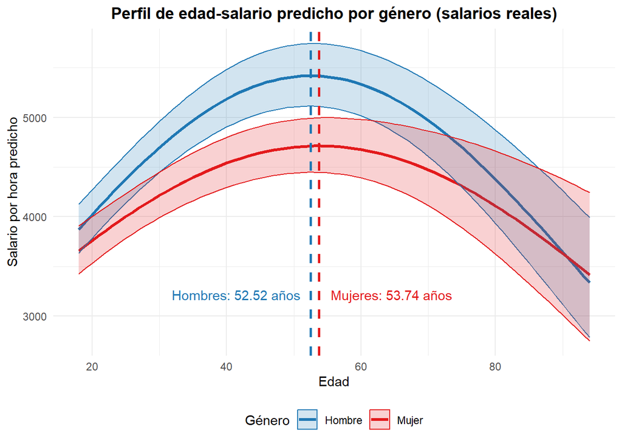

Aunque existe una diferencia relativamente pequeña entre la edad pico salarial, esto podría reflejar dinámicas laborales específicas de género como que las mujeres tienen interrupciones en su carrera laboral debido a responsabilidades de cuidado (por ejemplo, maternidad o cuidado de familiares), lo que retrasa ligeramente el pico salarial. Mientras que los hombres podrían tener una progresión salarial más continua y sin interrupciones significativas que demoren la llegada a su pico salarial.

La brecha salarial incondicional, que refleja la diferencia salarial entre hombres y mujeres sin considerar otras variables, es del 6.15% en este análisis, indicando que las mujeres ganan, en promedio, un 6.15% menos que los hombres. Sin embargo, al controlar por características observables como educación, experiencia, ocupación y otros factores laborales, la brecha salarial condicional aumenta al 11.52%, lo que sugiere que las mujeres enfrentan una desventaja salarial aún mayor cuando se comparan con hombres que tienen características similares. Este incremento en la brecha condicional es evidencia de que las mujeres poseen atributos que, en teoría, deberían asociarse con salarios más altos, pero aún así reciben remuneraciones inferiores. Este fenómeno podría estar relacionado con un problema de discriminación, donde las mujeres son penalizadas en el mercado laboral debido a prejuicios de género, prácticas salariales inequitativas o barreras en la promoción. Aunque parte de la brecha incondicional podría explicarse por diferencias en la selección de ocupaciones o interrupciones laborales (como las responsabilidades de cuidado), el aumento de la brecha al incluir controles indica que la discriminación, que es una variable no medible fácilmente, desempeña un papel significativo. Por lo tanto, es probable que la desigualdad salarial observada sea el resultado de una combinación de factores, donde la discriminación tiene un peso considerable, lo que subraya la necesidad de políticas que aborden tanto la equidad en el acceso a oportunidades como la eliminación de prácticas laborales discriminatorias.

# 5. Predicción del salario

En las secciones anteriores, estimaste algunas especificaciones con un enfoque en la inferencia. En esta subsección, evaluaremos el poder predictivo de estas especificaciones.

1. Divida la muestra en dos grupos: una muestra de entrenamiento (70%) y una de prueba (30%). (No olvide fijar una semilla para garantizar la reproducibilidad. En R, por ejemplo, puede usar `set.seed(10101)`, donde 10101 es la semilla).

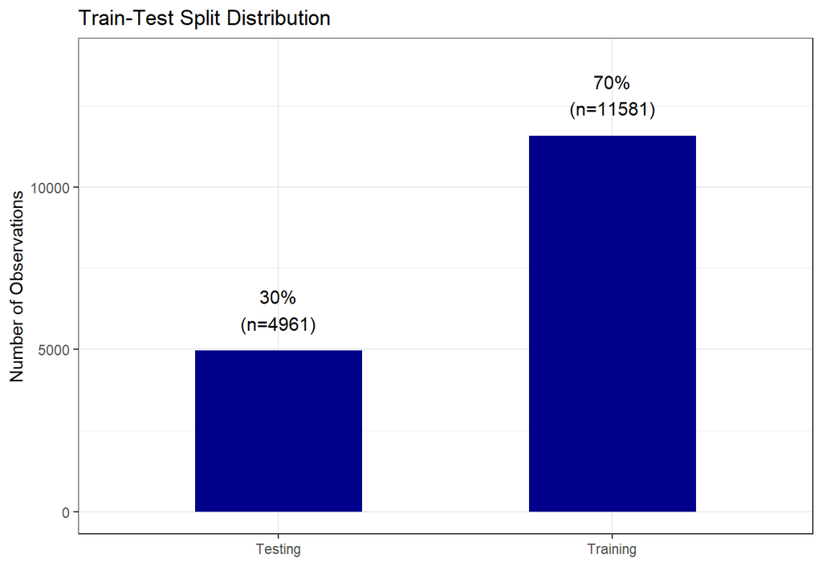

```r
#Definimos la semilla
set.seed(10101)

#Dividimos la muestra para el entrenamiento
indices <- createDataPartition(
  y = clean_geih$log_hourly_inglab,  ## La variable de interes
  p = .70, ## Porcentaje del set de entrenamiento
  list = FALSE
)

#Definición de datasets
training <- clean_geih %>%
  filter(row_number() %in% indices)

testing  <- clean_geih %>%
  filter(!row_number() %in% indices)

#Crear data para visualización
split_data <- data.frame(
  Split = factor(c("Training", "Testing")),
  Count = c(nrow(training), nrow(testing)),
  Percentage = c(nrow(training)/nrow(clean_geih)*100, nrow(testing)/nrow(clean_geih)*100)
)

#Crear visualización
ggplot(split_data, aes(x = Split, y = Count)) +
  geom_bar(stat = "identity", fill = "darkblue", width = 0.5) +
  geom_text(aes(label = paste0(round(Percentage, 1), "%\n(n=", Count, ")")),
            vjust = -0.5, color = "black", size = 4) +
  labs(title = "Train-Test Split Distribution",
       y = "Number of Observations",
       x = "") +
  theme_bw() +
  ylim(0, max(split_data$Count) * 1.2)
```

2. Reporte y compare el desempeño predictivo en términos del RMSE de todas las especificaciones anteriores junto con al menos cinco (5) especificaciones adicionales que exploren no linealidades y mayor complejidad.

   ```r
   # Predecir en el conjunto de prueba

   #modelo edad lineal
   modelo_edad <- lm(log_hourly_inglab ~ age + age_sq, data = clean_geih)

   #modelo edad bootstrap
   boot_model<- lm(log_hourly_inglab ~ age + age_sq, data = clean_geih)

   #Incluir el modelo de género

   #Incluir el modelo de género con condicionado

   #modelo efecto de la edad (age) sobre el ingreso varía según el género (female).

   modelo_interaccion_age_female <- lm(log_hourly_inglab ~ age + age_sq + female + age:female, data = clean_geih)

   #Modelo si el efecto de la edad varía según la formalidad laboral (formal).

   modelo_polinomico_age_formal <- lm(log_hourly_inglab ~ age + age_sq + I(age^3) + formal + age:formal, data = clean_geih)

   #Modelo si el efecto del estrato socioeconómico (estrato) sobre el ingreso varía según el tamaño de la empresa (sizefirm).

   modelo_interaccion_estrato_sizefirm <- lm(log_hourly_inglab ~ age + age_sq + estrato1 + sizeFirm + estrato1:sizeFirm, data = clean_geih)

   #Modelo si el efecto del tamaño de la empresa varía según el tipo de empleo (cuentapropia).

   modelo_log_sizefirm_cuentapropia <- lm(log_hourly_inglab ~ age + age_sq + log(sizeFirm + 1) + cuentaPropia + log(sizeFirm + 1):cuentaPropia, data = clean_geih)

   #Modelo efectos fijos para la ocupación (oficio).

   modelo_efectos_fijos_oficio <- lm(log_hourly_inglab ~ age + age_sq + I(age^3) + factor(oficio), data = clean_geih)

   predicciones1 <- predict(modelo_edad, newdata = testing)
   predicciones2 <- predict(boot_model, newdata = testing, interval = "confidence")
   predicciones3 <- predict(modelo_interaccion_age_female, newdata = testing)
   predicciones4 <- predict(modelo_polinomico_age_formal, newdata = testing)
   predicciones5 <- predict(modelo_interaccion_estrato_sizefirm, newdata = testing)
   predicciones6 <- predict(modelo_log_sizefirm_cuentapropia, newdata = testing)
   predicciones7 <- predict(modelo_efectos_fijos_oficio, newdata = testing)

   # Calcular RMSE para cada modelo

   rmse1 <- RMSE(predicciones1, testing$log_hourly_inglab)
   rmse2 <- RMSE(predicciones2, testing$log_hourly_inglab)
   rmse3 <- RMSE(predicciones3, testing$log_hourly_inglab)
   rmse4 <- RMSE(predicciones4, testing$log_hourly_inglab)
   rmse5 <- RMSE(predicciones5, testing$log_hourly_inglab)
   rmse6 <- RMSE(predicciones6, testing$log_hourly_inglab)
   rmse7 <- RMSE(predicciones7, testing$log_hourly_inglab)


   # Crear una tabla con los resultados
   resultados <- data.frame(
     Modelo = c("Modelo lineal", "Modelo bootstrap", "Modelo age:female", "Modelo age:formal", "Modelo estrato:sizefirm", "Modelo log(sizefirm):cuentapropia", "Modelo efectos fijos"),
     RMSE = c(rmse1, rmse2, rmse3, rmse4, rmse5, rmse6, rmse7 )
   )

   print(resultados)
   ```

   ```
   ##                              Modelo      RMSE
   ## 1                     Modelo lineal 0.8555251
   ## 2                  Modelo bootstrap 0.8557229
   ## 3                 Modelo age:female 0.8538207
   ## 4                 Modelo age:formal 0.7887830
   ## 5           Modelo estrato:sizefirm 0.7056719
   ## 6 Modelo log(sizefirm):cuentapropia 0.7993673
   ## 7              Modelo efectos fijos 0.7031694
   ```

3. En la discusión de los resultados, comente:

   i. El desempeño general de los modelos.

   Los modelos que incluyen interacciones y efectos fijos (estrato:sizefirm y efectos fijos) tienen un desempeño predictivo superior en comparación con los modelos más simples (lineal y bootstrap). Esto sugiere que las relaciones no lineales y las interacciones entre variables son importantes para predecir el ingreso laboral.
   2. La especificación con el menor error de predicción.